# Week 3 solutions

```r
library(daggity)
```

```
Error in library(daggity) : there is no package called ‘daggity’
```

# Preview & understand the data

```r
summary(foxes)
```

```
     group          avgfood         groupsize          area           weight
 Min.   : 1.00   Min.   :0.3700   Min.   :2.000   Min.   :1.090   Min.   :1.920
 1st Qu.:11.75   1st Qu.:0.6600   1st Qu.:3.000   1st Qu.:2.590   1st Qu.:3.720
 Median :18.00   Median :0.7350   Median :4.000   Median :3.130   Median :4.420
 Mean   :17.21   Mean   :0.7517   Mean   :4.345   Mean   :3.169   Mean   :4.530
 3rd Qu.:24.00   3rd Qu.:0.8000   3rd Qu.:5.000   3rd Qu.:3.772   3rd Qu.:5.375
 Max.   :30.00   Max.   :1.2100   Max.   :8.000   Max.   :5.070   Max.   :7.550
```

# Exercise 1

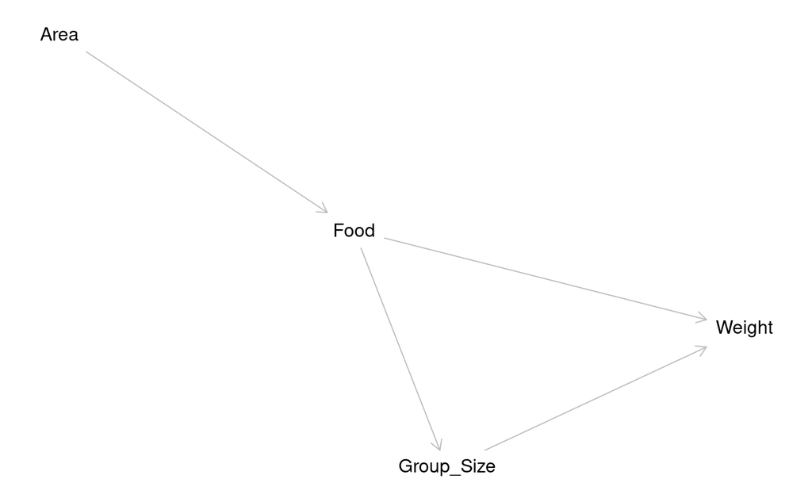

```r
dag = dagitty("dag {
  Area -> Food;
  Food -> Group_Size;
  Group_Size -> Weight;
  Food -> Weight
}", layout = T)

outcomes(dag) = "Food"
exposures(dag) = "Area"

plot(dag)
```

To estimate the total causal effect of `Area` to `Food`, we don’t need any adjustments.

```r
dt = list(
  Food = standardize(foxes$avgfood),
  Area = standardize(foxes$area)
)

model = quap(
  flist = alist(
    Food ~ dnorm(mu, sigma),
    mu <- bf * Area,
    bf ~ dnorm(0, 1),
    sigma ~ dexp(1)
  ),
  data=dt
)

precis(model)
```

|  | mean | sd | 5.5% | 94.5% |
| --- | --- | --- | --- | --- |
| bf | 0.88 | 0.04 | 0.81 | 0.95 |
| sigma | 0.47 | 0.03 | 0.42 | 0.51 |

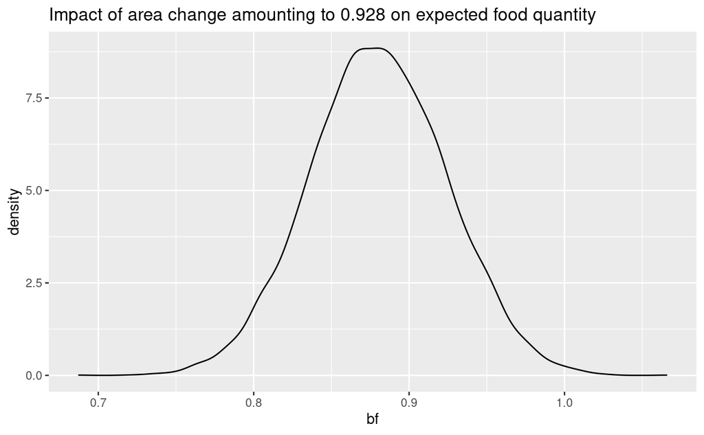

```r
samples = extract.samples(model)

ggplot(samples) + geom_density(aes(x=bf)) + labs(
  title=paste(
    'Impact of area change amounting to',
    round(sd(foxes$area),3),
    'on expected food quantity'
  )
)
```

It’s interesting that a non-centered model yields parameters closer to 0..

```r
model_noncentered = quap(
  flist = alist(
    avgfood ~ dnorm(mu, sigma),
    mu <- a + bf * area,
    bf ~ dnorm(0, 1),
    a ~ dnorm(0, 1),
    sigma ~ dexp(1)
  ),
  data=foxes
)

precis(model_noncentered)
```

|  | mean | sd | 5.5% | 94.5% |
| --- | --- | --- | --- | --- |
| bf | 0.19 | 0.01 | 0.17 | 0.2 |
| a | 0.15 | 0.03 | 0.10 | 0.2 |
| sigma | 0.09 | 0.01 | 0.08 | 0.1 |

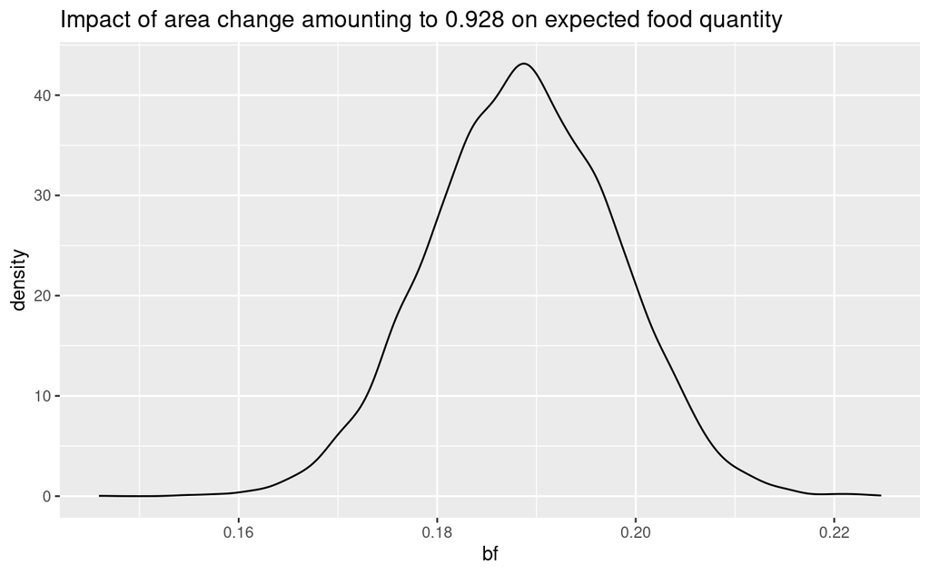

```r
samples = extract.samples(model_noncentered)

ggplot(samples) + geom_density(aes(x=bf)) + labs(
  title=paste(
    'Impact of area change amounting to',
    round(sd(foxes$area),3),
    'on expected food quantity'
  )
)
```

How about using Student-T distribution to account for outliers?

```r
model_student_non_centered = quap(
  flist = alist(
    avgfood ~ dstudent(2, mu, sigma),
    mu <- a + bf * area,
    bf ~ dnorm(0, 1),
    a ~ dnorm(0, 1),
    sigma ~ dexp(1)
  ),
  data=foxes
)

precis(model_student_non_centered)
```

|  | mean | sd | 5.5% | 94.5% |
| --- | --- | --- | --- | --- |
| bf | 0.19 | 0.01 | 0.17 | 0.22 |
| a | 0.14 | 0.04 | 0.08 | 0.21 |
| sigma | 0.08 | 0.01 | 0.06 | 0.09 |

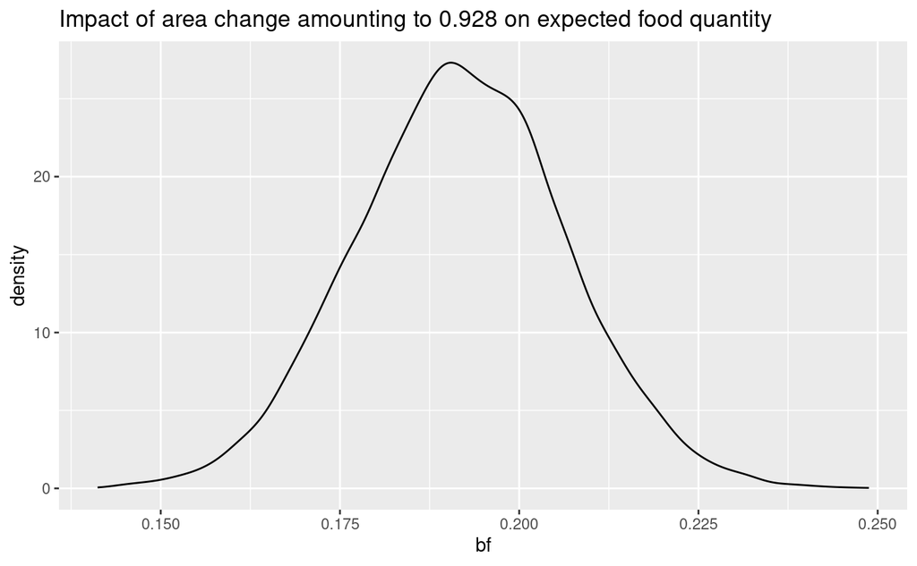

```r
samples = extract.samples(model_student_non_centered)

ggplot(samples) + geom_density(aes(x=bf)) + labs(
  title=paste(
    'Impact of area change amounting to',
    round(sd(foxes$area),3),
    'on expected food quantity'
  )
)
```

```r
model_student = quap(
  flist = alist(
    Food ~ dstudent(2, mu, sigma),
    mu <- bf * Area,
    bf ~ dnorm(0, 1),
    sigma ~ dexp(1)
  ),
  data=dt
)

precis(model_student)
```

|  | mean | sd | 5.5% | 94.5% |
| --- | --- | --- | --- | --- |
| bf | 0.90 | 0.06 | 0.80 | 0.99 |
| sigma | 0.38 | 0.03 | 0.33 | 0.44 |

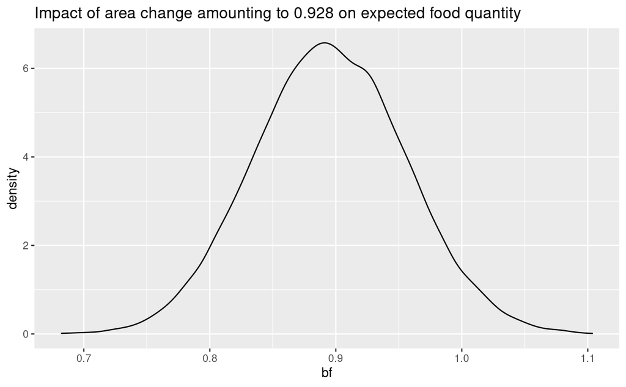

```r
samples = extract.samples(model_student)

ggplot(samples) + geom_density(aes(x=bf)) + labs(
  title=paste(
    'Impact of area change amounting to',
    round(sd(foxes$area),3),
    'on expected food quantity'
  )
)
```

Which one is the best? They all use the same causal DAG, so I could use PSIS/WAIC to assess. Weirdly, the “least confident” model is actually the best `\_(0_o)_/`

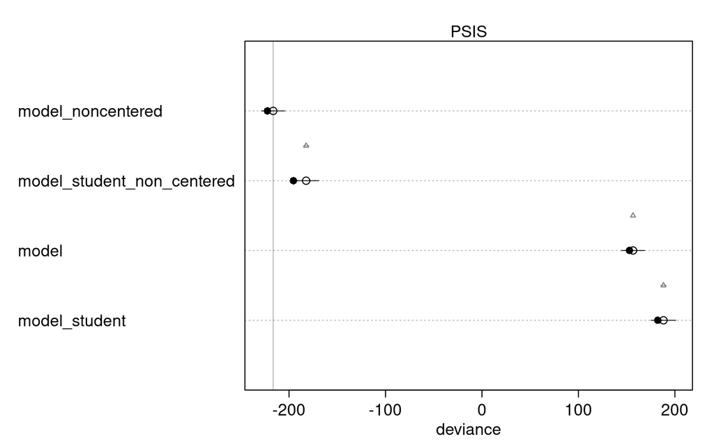

we could also look at estimate of actual food, not expected value. I’ll use the mean-centered model as it’s easier to interpret

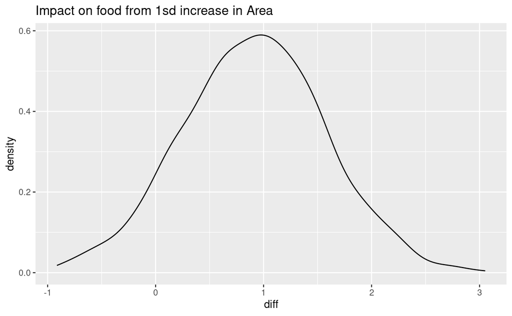

```r
food_average_area = sim(model, data=list(Area=0))
food_1sd_increase = sim(model, data=list(Area=1))

diff_in_food = tibble(diff=food_1sd_increase - food_average_area)

ggplot(diff_in_food) + geom_density(aes(x=diff)) + ggtitle("Impact on food from 1sd increase in Area")
```

# Exercise 2

Total causal effect of food on W. We don’t stratify by anything again.

```r
ex2_dt = list(
  Food = standardize(foxes$avgfood),
  Weight = standardize(foxes$weight)
)

ex2_model = quap(
  flist = alist(
    Weight ~ dnorm(mu, sigma),
    mu <- bw * Food,
    bw ~ dnorm(0, 1),
    sigma ~ dexp(1)
  ),
  data=ex2_dt
)

precis(ex2_model)
```

|  | mean | sd | 5.5% | 94.5% |
| --- | --- | --- | --- | --- |
| bw | -0.02 | 0.09 | -0.17 | 0.12 |
| sigma | 0.99 | 0.06 | 0.89 | 1.09 |

[figure not shown]

```r
ex2_samples = extract.samples(ex2_model)

ggplot(ex2_samples) + geom_density(aes(x=bw)) + labs(
  title=paste(
    'Impact of area change amounting to',
    round(sd(foxes$avgfood),3),
    'on expected food quantity'
  )
)
```

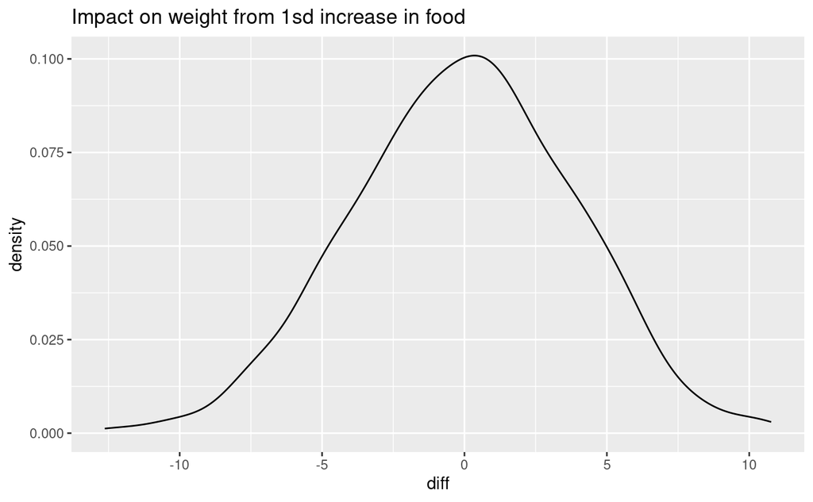

```r
weight_average_food = sim(ex2_model, data=list(Food=0))
weight_food_increase = sim(ex2_model, data=list(Food=1))

diff_in_weight = tibble(diff=weight_food_increase - weight_average_food)

ggplot(diff_in_weight) + geom_density(aes(x=diff)) + ggtitle("Impact on weight from 1sd increase in food")
```

# Ex3

It looks like that more food leads to more weight, if group size does not change. However, in reality, food leads to group size increases, and these offset the impact of food availability on weight. Basically, foxes use food surplus to increase their “gang” sizes rather than gain weight.

```r
ex3_dt = list(
  Food = standardize(foxes$avgfood),
  Weight = standardize(foxes$weight),
  Group = standardize(foxes$groupsize)
)

ex3_model = quap(
  flist = alist(
    Weight ~ dnorm(mu, sigma),
    mu <- bf * Food + bw*Group,
    bw ~ dnorm(0, 0.5),
    bf ~ dnorm(0, 0.5),
    sigma ~ dexp(1),
    Weight ~ dnorm(mu_total, sigma_total),
    mu_total <- bf_total * Food,
    bf_total ~ dnorm(0, 1),
    sigma_total ~ dexp(1)
  ),
  data=ex3_dt
)

precis(ex3_model)
```

|  | mean | sd | 5.5% | 94.5% |
| --- | --- | --- | --- | --- |
| bw | -0.57 | 0.18 | -0.86 | -0.29 |
| bf | 0.48 | 0.18 | 0.19 | 0.76 |
| sigma | 0.94 | 0.06 | 0.84 | 1.04 |
| bf_total | -0.02 | 0.09 | -0.17 | 0.12 |
| sigma_total | 0.99 | 0.06 | 0.89 | 1.09 |

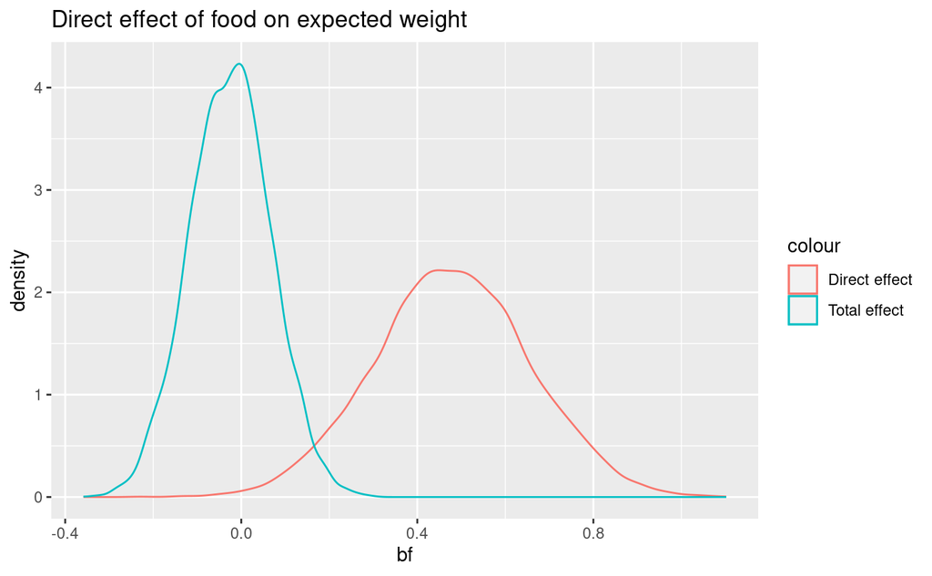

```r
ex3_samples = extract.samples(ex3_model)

ggplot(ex3_samples) + geom_density(aes(x=bf, color='Direct effect')) +
  geom_density(aes(x=bf_total, color='Total effect')) +
  labs(
  title=paste(
    'Direct effect of food on expected weight'
  )
)
```

# Exercise 4

Can we do this with instrumental variables?

[figure not shown]

```r
sim = function(n=10000, bAF=0.88, bUF=0, bFG=0.9, bUG=0, bFW=0.47, bGW=-0.57, Fsigma=1) {
  Area = rnorm(n)
  U = rnorm(n)
  Food = rnorm(n, bAF * Area + bUF * U, Fsigma)
  Group = rnorm(n, bFG * Food + bUG * U)
  Weight = rnorm(n, bFW * Food + bGW * Group)

  tibble(Area, Food, Group, Weight)
}
```

```r
data = sim(bFW=0.47, bUF=1, bUG=-1, Fsigma=0.1)

ex4_model_instrument = quap(
  flist = alist(
    Weight ~ dnorm(mu, sigma),
    Weight ~ dnorm(mu_total, sigma_total),
    Food ~ dnorm(mu_f, sigma_area),
    mu_f <- Area * ba,
    mu <- bf * mu_f + bw*Group,
    mu_total <- bf_total * mu_f,
    ba ~ dnorm(0, 0.5),
    bw ~ dnorm(0, 0.5),
    bf ~ dnorm(0, 0.5),
    bf_total ~ dnorm(0, 0.5),
    sigma ~ dexp(1),
    sigma_total ~ dexp(1),
    sigma_area ~ dexp(1)
  ),
  data=data
)

precis(ex4_model_instrument)
```

|  | mean | sd | 5.5% | 94.5% |
| --- | --- | --- | --- | --- |
| ba | 0.88 | 0.01 | 0.87 | 0.90 |
| bw | -0.60 | 0.01 | -0.62 | -0.58 |
| bf | 0.52 | 0.02 | 0.50 | 0.55 |
| bf_total | -0.01 | 0.01 | -0.04 | 0.01 |
| sigma | 1.10 | 0.01 | 1.09 | 1.11 |
| sigma_total | 1.26 | 0.01 | 1.25 | 1.27 |
| sigma_area | 1.01 | 0.01 | 1.00 | 1.02 |

```r
NA
```